# IODS course project

# 3 Logistic regression

### 3.1. Data Wrangling

After completing the Exercise set 2, I did the first part of the Assignment 3; Data wrangling. The R script for that can be found [here](https://github.com/kreikka/IODS-project/blob/master/data/create_alc.R)

### 3.2. Reading and Exploring the data

Reading the data created in Data Wrangling part from a local folder:

```r
# access all the libraries needed in the assignment 3:
library(dplyr)
library(tidyverse)
library(GGally)
library(ggplot2)

# Read the .csv file created in the Data wrangling:
alc <- read_csv(file="C:\\Users\\kuud\\Work Folders\\IODS\\IODS-project\\data\\alc.csv")
```

The data attributes include Portuguese secondary education student grades (first, second and final grade; G1-G3), socio-demographic and education related features, and it was collected by using school reports and questionnaires. This data set **alc** combines two data in two distinct subjects; Mathematics (mat) and Portuguese language (por). More information about the open data sets used in this Assignment can be found [here](http://www.archive.ics.uci.edu/dataset/320/student+performance). In addition to the original variables this data has two additional alcohol-related variables: **alc_use** is the average of **Dalc** (Workday alcohol consumption) and **Walc** (weekend alcohol consumption) and **high_use** is TRUE if **alc_use** is higher than 2 and FALSE otherwise. The list of variables is shown below.

```r
# Column names of the data set
colnames(alc)
```

```
##  [1] "school"     "sex"        "age"        "address"    "famsize"
##  [6] "Pstatus"    "Medu"       "Fedu"       "Mjob"       "Fjob"
## [11] "reason"     "guardian"   "traveltime" "studytime"  "schoolsup"
## [16] "famsup"     "activities" "nursery"    "higher"     "internet"
## [21] "romantic"   "famrel"     "freetime"   "goout"      "Dalc"
## [26] "Walc"       "health"     "failures"   "paid"       "absences"
## [31] "G1"         "G2"         "G3"         "alc_use"    "high_use"
```

### 3.3. Choosing the variables

> Assignment: *Choose 4 interesting variables in the data and for each of them, present your personal hypothesis about their relationships with alcohol consumption.*

There are many interesting variables to choose from, but here I wanted to examine the possible effect of the family socioeconomic status (SES) and family relationships on students alcohol consumption, so I chose the parents education (**Medu** = mothers education, **Fedu** = fathers education), home address type (**address** = urban or rural) and the quality of family relationships (**famrel**). Income would have been a nice addition, but that information was not collected. My hypothesis is that higher education of the parents, living in urban area and having a good family relations might predict using less alcohol. I’m interested to see if mothers and fathers education have differ on the effect they have on their childrens alcohol consumption. Although alcohol use is a bit difficult to predict with different socioeconomic variables, since for example drinking wine with meals is usually more typical in middle-high and high-income families, when drinking beer and other similar beverages might be more common in low-income families, at least in some countries. Let’s see what this data has to say about the relationship of family SES and relationships with students alcohol consumption.

##### **Mothers and fathers education (Medu & Fedu):**

Let’s explore the parents education:

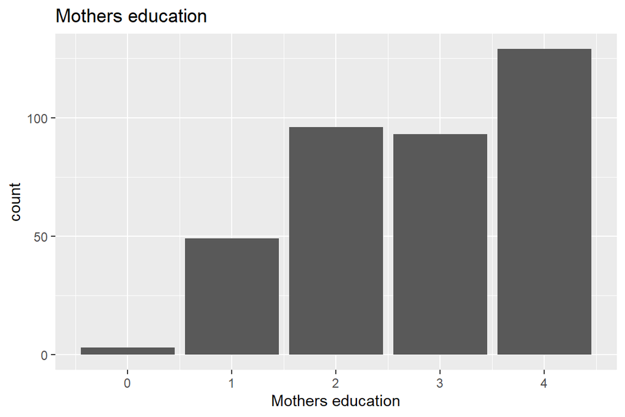

```r
# Mothers education
me <- ggplot(data = alc, aes(x = Medu)) +
  geom_bar() +
  ggtitle("Mothers education") +
  xlab("Mothers education")
me
```

```r
# frequency table
table(alc$Medu)
```

```
##
##   0   1   2   3   4
##   3  49  96  93 129
```

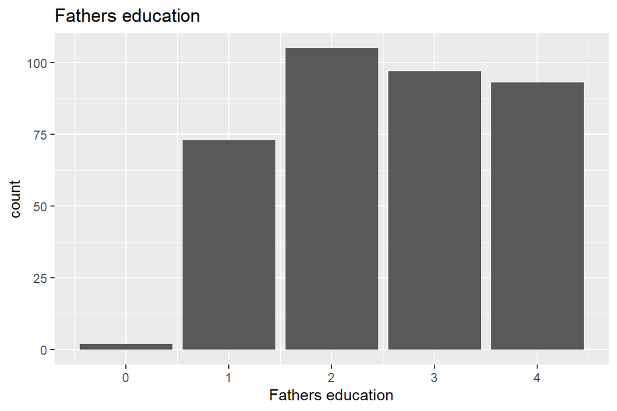

```r
# Fathers education
fe <- ggplot(data = alc, aes(x = Fedu)) +
  geom_bar() +
  ggtitle("Fathers education") +
  xlab("Fathers education")
fe
```

```r
# frequency table
table(alc$Fedu)
```

```
##
##   0   1   2   3   4
##   2  73 105  97  93
```

It seems that there are only 3 mothers and 2 fathers with no education (0 = no education). I decided to combine the “no education” to “primary education” (see below), so that the new variables are **Medu_cat** and **Fedu_cat** with the following data: 1 = primary education (4th grade) or less, 2 = 5th to 9th grade, 3 = secondary education and 4 = higher education.

```r
# Recoding the no education category 0 into 1 for mothers education
alc$Medu_cat <- recode(alc$Medu, '0' = 1)
# checking the frequency table of the new variable compared to the origial
table(alc$Medu)
```

```
##
##   0   1   2   3   4
##   3  49  96  93 129
```

```r
table(alc$Medu_cat)
```

```
##
##   1   2   3   4
##  52  96  93 129
```

```r
# Recoding the no education category 0 into 1 for fathers education
alc$Fedu_cat <- recode(alc$Fedu, '0' = 1)
# checking the frequency tables of the new variable compared to the origial
table(alc$Fedu)
```

```
##
##   0   1   2   3   4
##   2  73 105  97  93
```

```r
table(alc$Fedu_cat)
```

```
##
##   1   2   3   4
##  75 105  97  93
```

##### **Address:**

It seems that majority of the students lives in urban area.

```r
# frequency table
table(alc$address)
```

```
##
##   R   U
##  81 289
```

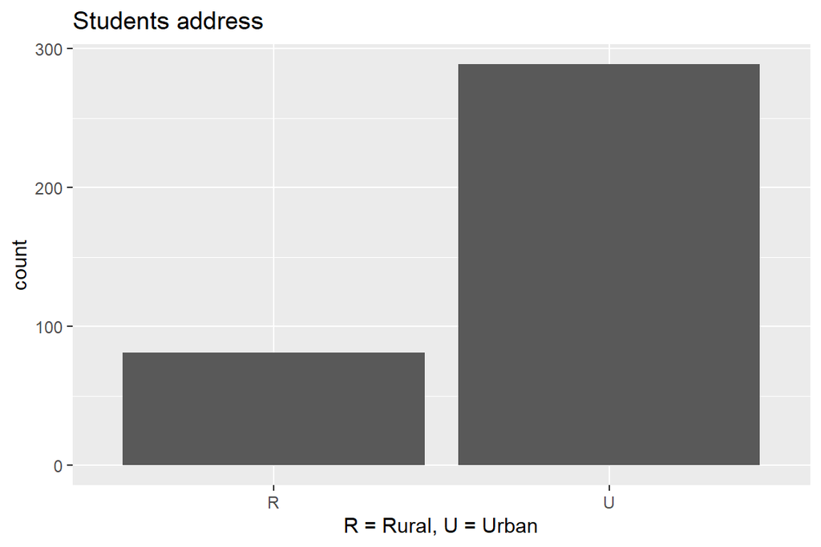

```r
# Plot
ad <- ggplot(data = alc, aes(x = address)) +
  geom_bar() +
  ggtitle("Students address") +
  xlab("R = Rural, U = Urban")
ad
```

#### **Guality of family relationships:**

Majority of the students (about 75 %) have very good family relations (4 or 5 on a 1-5 scale), but also worse relations exists.

```r
# frequency table
table(alc$famrel)
```

```
##
##   1   2   3   4   5
##   8  18  64 180 100
```

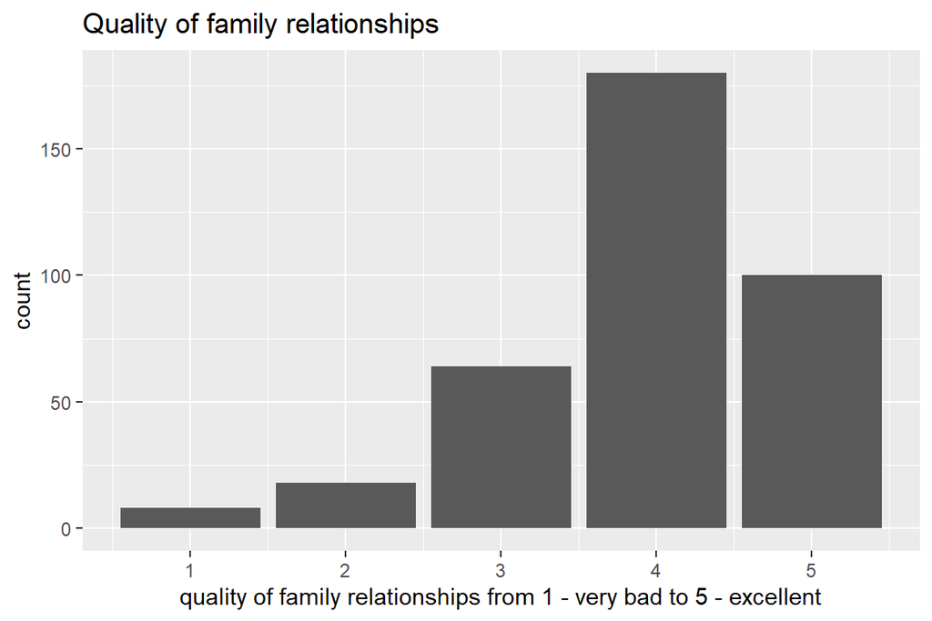

```r
# Plot
fam <- ggplot(data = alc, aes(x = famrel)) +
  geom_bar() +
  ggtitle("Quality of family relationships") +
  xlab("quality of family relationships from 1 - very bad to 5 - excellent")
fam
```

#### **Alcohol consumption:**

Let’s explore also the alcohol use (**alc_use**) and high consumption of alcohol (**high_use**) in this data:.

```r
# frequency table
table(alc$alc_use)
```

```
##
##   1 1.5   2 2.5   3 3.5   4 4.5   5
## 140  63  56  41  32  17   9   3   9
```

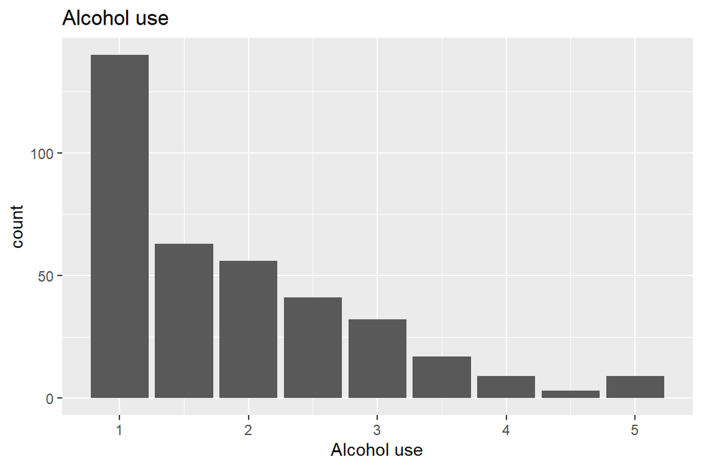

```r
# Plot
au <- ggplot(data = alc, aes(x = alc_use)) +
  geom_bar() +
  ggtitle("Alcohol use") +
  xlab("Alcohol use")
au
```

```r
# frequency table
table(alc$alc_use)
```

```
##
##   1 1.5   2 2.5   3 3.5   4 4.5   5
## 140  63  56  41  32  17   9   3   9
```

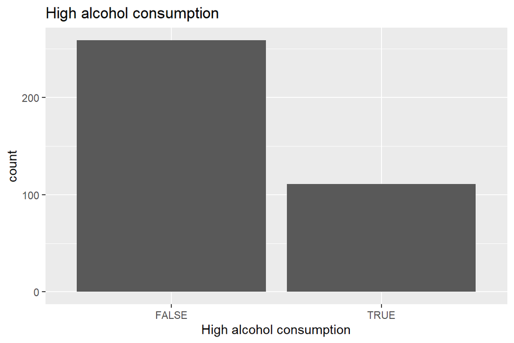

```r
# Plot
hu <- ggplot(data = alc, aes(x = high_use)) +
  geom_bar() +
  ggtitle("High alcohol consumption") +
  xlab("High alcohol consumption")
hu
```

### 3.4. Relationship between the chosen variables and alcohol consumption

Next, I’ll explore the relationships of **Medu_cat**, **Fedu_cat** (parents education categorised into 4), **address** (urban and rural) and **famrel** (scale from 1 - bad to 5 - excellent) to high alcohol consumption: **high_use**.

```r
# percentage frequency table; high_use and mothers education
table1 <- table(alc$Medu_cat, alc$high_use)
round(prop.table(table1), 3)
```

```
##
##     FALSE  TRUE
##   1 0.086 0.054
##   2 0.211 0.049
##   3 0.154 0.097
##   4 0.249 0.100
```

```r
# percentage frequency table; high_use and fathers education
table2 <- table(alc$Fedu_cat, alc$high_use)
round(prop.table(table2), 3)
```

```
##
##     FALSE  TRUE
##   1 0.138 0.065
##   2 0.203 0.081
##   3 0.189 0.073
##   4 0.170 0.081
```

```r
# percentage frequency table; high_use and address
table3 <- table(alc$address, alc$high_use)
round(prop.table(table3), 3)
```

```
##
##     FALSE  TRUE
##   R 0.135 0.084
##   U 0.565 0.216
```

```r
# percentage frequency table; high_use and famrel
table4 <- table(alc$famrel, alc$high_use)
round(prop.table(table4), 3)
```

```
##
##     FALSE  TRUE
##   1 0.016 0.005
##   2 0.024 0.024
##   3 0.105 0.068
##   4 0.346 0.141
##   5 0.208 0.062
```

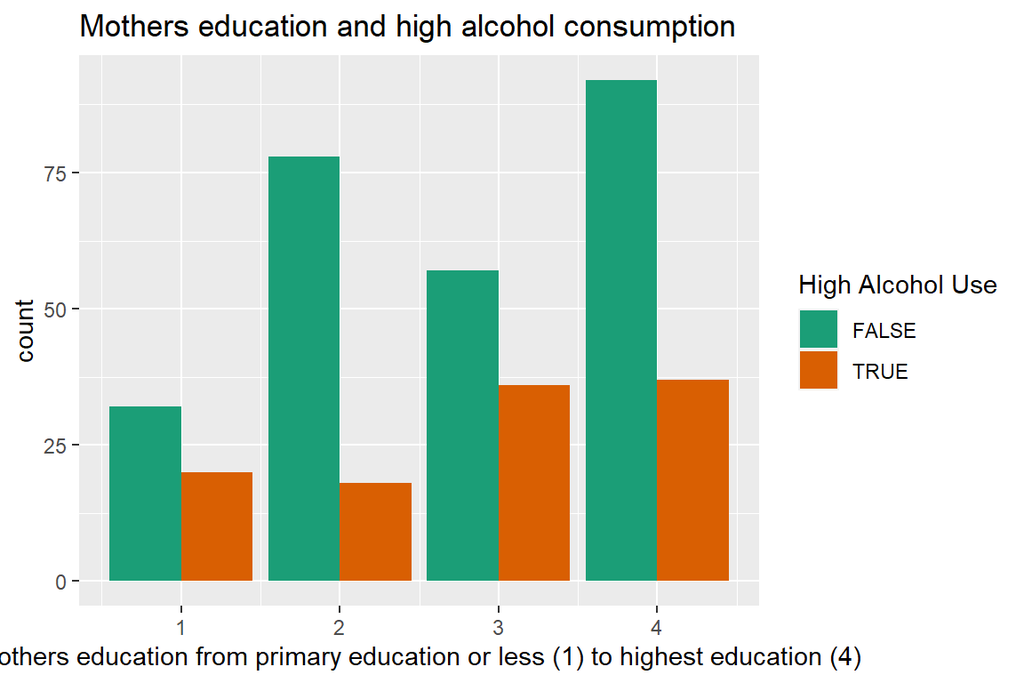

```r
# Bar-plots:
# high_use by mothers education

mehu <- ggplot(data = alc, aes(x = Medu_cat, fill = high_use)) +
  geom_bar(position=position_dodge()) +
  ggtitle("Mothers education and high alcohol consumption") +
  xlab("Mothers education from primary education or less (1) to highest education (4)") +
  scale_fill_brewer(palette="Dark2") +
  labs(fill="High Alcohol Use")
mehu
```

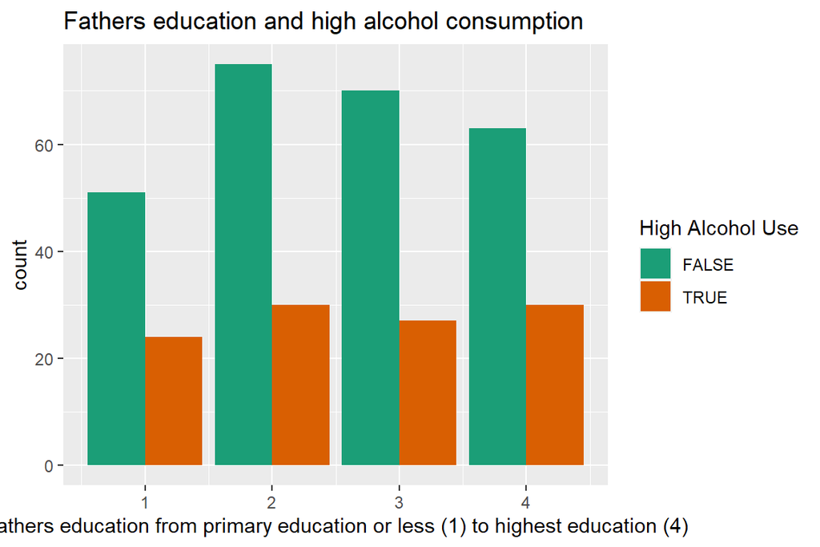

```r
# high_use by fathers education
fehu <- ggplot(data = alc, aes(x = Fedu_cat, fill = high_use)) +
  geom_bar(position=position_dodge()) +
  ggtitle("Fathers education and high alcohol consumption") +
  xlab("Fathers education from primary education or less (1) to highest education (4)") +
  scale_fill_brewer(palette="Dark2") +
  labs(fill="High Alcohol Use")
fehu
```

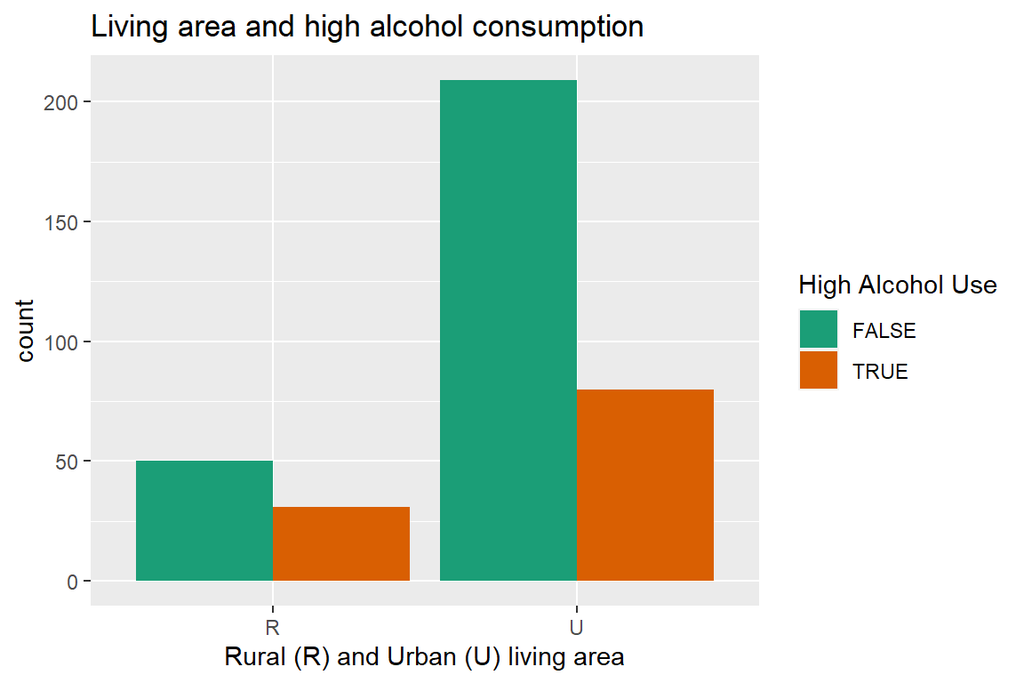

```r
# high_use by address
adhu <- ggplot(data = alc, aes(x = address, fill = high_use)) +
  geom_bar(position=position_dodge()) +
  ggtitle("Living area and high alcohol consumption") +
  xlab("Rural (R) and Urban (U) living area") +
  scale_fill_brewer(palette="Dark2") +
  labs(fill="High Alcohol Use")
adhu
```

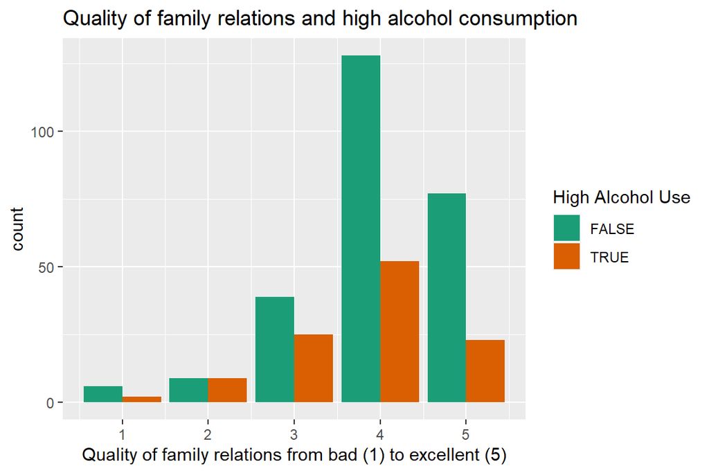

```r
# high_use by quality of family relations
fahu <- ggplot(data = alc, aes(x = famrel, fill = high_use)) +
  geom_bar(position=position_dodge()) +
  ggtitle("Quality of family relations and high alcohol consumption") +
  xlab("Quality of family relations from bad (1) to excellent (5)") +
  scale_fill_brewer(palette="Dark2") +
  labs(fill="High Alcohol Use")
fahu
```

```r
# Summary statistics by group
alc %>% group_by(Medu_cat, high_use) %>% summarise(count = n())
```

```
## # A tibble: 8 × 3
## # Groups:   Medu_cat [4]
##   Medu_cat high_use count
##      <dbl> <lgl>    <int>
## 1        1 FALSE       32
## 2        1 TRUE        20
## 3        2 FALSE       78
## 4        2 TRUE        18
## 5        3 FALSE       57
## 6        3 TRUE        36
## 7        4 FALSE       92
## 8        4 TRUE        37
```

```r
alc %>% group_by(Fedu_cat, high_use) %>% summarise(count = n())
```

```
## # A tibble: 8 × 3
## # Groups:   Fedu_cat [4]
##   Fedu_cat high_use count
##      <dbl> <lgl>    <int>
## 1        1 FALSE       51
## 2        1 TRUE        24
## 3        2 FALSE       75
## 4        2 TRUE        30
## 5        3 FALSE       70
## 6        3 TRUE        27
## 7        4 FALSE       63
## 8        4 TRUE        30
```

```r
alc %>% group_by(address, high_use) %>% summarise(count = n())
```

```
## # A tibble: 4 × 3
## # Groups:   address [2]
##   address high_use count
##   <chr>   <lgl>    <int>
## 1 R       FALSE       50
## 2 R       TRUE        31
## 3 U       FALSE      209
## 4 U       TRUE        80
```

```r
alc %>% group_by(famrel, high_use) %>% summarise(count = n())
```

```
## # A tibble: 10 × 3
## # Groups:   famrel [5]
##    famrel high_use count
##     <dbl> <lgl>    <int>
##  1      1 FALSE        6
##  2      1 TRUE         2
##  3      2 FALSE        9
##  4      2 TRUE         9
##  5      3 FALSE       39
##  6      3 TRUE        25
##  7      4 FALSE      128
##  8      4 TRUE        52
##  9      5 FALSE       77
## 10      5 TRUE        23
```

### 3.5. Logistic regression

Let’s make a logistic regression with the values we have. The goal is to see whether variables predict binary value of high consumption of alcohol.

```r
# logistic regression model and summary of the model
m <- glm(high_use ~ Medu_cat + Fedu_cat + address + famrel, data = alc, family = "binomial")
# summary of the model
summary(m)
```

```
##
## Call:
## glm(formula = high_use ~ Medu_cat + Fedu_cat + address + famrel,
##     family = "binomial", data = alc)
##
## Deviance Residuals:
##     Min       1Q   Median       3Q      Max
## -1.2190  -0.8369  -0.7768   1.3875   1.7687
##
## Coefficients:
##              Estimate Std. Error z value Pr(>|z|)
## (Intercept)  0.536638   0.606040   0.885   0.3759
## Medu_cat     0.027316   0.141754   0.193   0.8472
## Fedu_cat     0.003706   0.139400   0.027   0.9788
## addressU    -0.488253   0.268969  -1.815   0.0695 .
## famrel      -0.281729   0.122926  -2.292   0.0219 *
## ---
## Signif. codes:  0 '***' 0.001 '**' 0.01 '*' 0.05 '.' 0.1 ' ' 1
##
## (Dispersion parameter for binomial family taken to be 1)
##
##     Null deviance: 452.04  on 369  degrees of freedom
## Residual deviance: 443.43  on 365  degrees of freedom
## AIC: 453.43
##
## Number of Fisher Scoring iterations: 4
```

```r
# compute odds ratios (OR) and confidence intervals (CI) and print out
OR <- coef(m) %>% exp
CI <- confint(m) %>% exp()
cbind(OR, CI)
```

```
##                    OR     2.5 %    97.5 %
## (Intercept) 1.7102475 0.5195260 5.6330075
## Medu_cat    1.0276927 0.7781323 1.3582376
## Fedu_cat    1.0037127 0.7636785 1.3207660
## addressU    0.6136974 0.3632679 1.0456781
## famrel      0.7544783 0.5918643 0.9600937
```

It’s a bit boring to have only one variable predicting the high alcohol use in this model, but below I’m exploring the predictive power of the model, mainly to learn how it is done.

```r
# include the only significant variable
m2 <- glm(high_use ~ famrel, data = alc, family = "binomial")

# predict() the probability of high_use
probabilities <- predict(m2, type = "response")

# add the predicted probabilities to 'alc' and use the probabilities to make a prediction high_use
alc <- mutate(alc, probability = probabilities)
alc <- mutate(alc, prediction = probability > 0.5)

# tabulate the target variable versus the predictions and probabilities
print(table(high_use = alc$high_use, prediction = alc$prediction))
```

```
##         prediction
## high_use FALSE
##    FALSE   259
##    TRUE    111
```

```r
print(table(high_use = alc$high_use, prediction = alc$prediction) %>% prop.table() %>% addmargins())
```

```
##         prediction
## high_use FALSE Sum
##    FALSE   0.7 0.7
##    TRUE    0.3 0.3
##    Sum     1.0 1.0
```

As you would guess, this model does not give much more information compared to the simple guessing from the previous bar plots and frequency tables. The model predicts about one third wrong (111). If I would have had more time, I would have explored more variables and try to create a better model.

Finally, let’s calculate a loss function for the predictions and K-fold cross validation:

```r
# define a loss function (mean prediction error)
loss_func <- function(class, prob) {
  n_wrong <- abs(class - prob) > 0.5
  mean(n_wrong)
}

# call loss_func to compute the average number of wrong predictions in the (training) data
# note: in the RStudio editor, this outputs [1] 0.2891892 - I didn't have time to find out why it is rounded to 0.3 when knitted
loss_func(class = alc$high_use, prob = alc$probability)
```

```
## [1] 0.3
```

```r
# call loss_func to compute the average number of wrong predictions in the data when everyone is a high-user
loss_func(class = alc$high_use, prob = 0)
```

```
## [1] 0.3
```

```r
library(boot)
# K-fold cross validation
cv <- cv.glm(data = alc, cost = loss_func, glmfit = m2, K = nrow(alc))

# average number of wrong predictions in the cross validation
cv$delta[1]
```

```
## [1] 0.3162162
```

# 4 Clustering and classification

### 4.1. Exploring the dataset

The assignment 4 started with loading the *The Boston Housing*; `Boston` dataset. The dataset is openly available from the MASS-package in R. Below I look at the structure with `str()` and use `summary()` to see the details of the variables.

```r
# access the MASS package and all the other libraries needed for this Assignment
library(MASS)
library(dplyr)
library(tidyr)
library(ggplot2)
library(corrplot)

# load the data
data("Boston")

# explore the dataset structure, summary and missing data
str(Boston)
```

```
## 'data.frame':    506 obs. of  14 variables:
##  $ crim   : num  0.00632 0.02731 0.02729 0.03237 0.06905 ...
##  $ zn     : num  18 0 0 0 0 0 12.5 12.5 12.5 12.5 ...
##  $ indus  : num  2.31 7.07 7.07 2.18 2.18 2.18 7.87 7.87 7.87 7.87 ...
##  $ chas   : int  0 0 0 0 0 0 0 0 0 0 ...
##  $ nox    : num  0.538 0.469 0.469 0.458 0.458 0.458 0.524 0.524 0.524 0.524 ...
##  $ rm     : num  6.58 6.42 7.18 7 7.15 ...
##  $ age    : num  65.2 78.9 61.1 45.8 54.2 58.7 66.6 96.1 100 85.9 ...
##  $ dis    : num  4.09 4.97 4.97 6.06 6.06 ...
##  $ rad    : int  1 2 2 3 3 3 5 5 5 5 ...
##  $ tax    : num  296 242 242 222 222 222 311 311 311 311 ...
##  $ ptratio: num  15.3 17.8 17.8 18.7 18.7 18.7 15.2 15.2 15.2 15.2 ...
##  $ black  : num  397 397 393 395 397 ...
##  $ lstat  : num  4.98 9.14 4.03 2.94 5.33 ...
##  $ medv   : num  24 21.6 34.7 33.4 36.2 28.7 22.9 27.1 16.5 18.9 ...
```

```r
summary(Boston)
```

```
##       crim                zn             indus            chas
##  Min.   : 0.00632   Min.   :  0.00   Min.   : 0.46   Min.   :0.00000
##  1st Qu.: 0.08205   1st Qu.:  0.00   1st Qu.: 5.19   1st Qu.:0.00000
##  Median : 0.25651   Median :  0.00   Median : 9.69   Median :0.00000
##  Mean   : 3.61352   Mean   : 11.36   Mean   :11.14   Mean   :0.06917
##  3rd Qu.: 3.67708   3rd Qu.: 12.50   3rd Qu.:18.10   3rd Qu.:0.00000
##  Max.   :88.97620   Max.   :100.00   Max.   :27.74   Max.   :1.00000
##       nox               rm             age              dis
##  Min.   :0.3850   Min.   :3.561   Min.   :  2.90   Min.   : 1.130
##  1st Qu.:0.4490   1st Qu.:5.886   1st Qu.: 45.02   1st Qu.: 2.100
##  Median :0.5380   Median :6.208   Median : 77.50   Median : 3.207
##  Mean   :0.5547   Mean   :6.285   Mean   : 68.57   Mean   : 3.795
##  3rd Qu.:0.6240   3rd Qu.:6.623   3rd Qu.: 94.08   3rd Qu.: 5.188
##  Max.   :0.8710   Max.   :8.780   Max.   :100.00   Max.   :12.127
##       rad              tax           ptratio          black
##  Min.   : 1.000   Min.   :187.0   Min.   :12.60   Min.   :  0.32
##  1st Qu.: 4.000   1st Qu.:279.0   1st Qu.:17.40   1st Qu.:375.38
##  Median : 5.000   Median :330.0   Median :19.05   Median :391.44
##  Mean   : 9.549   Mean   :408.2   Mean   :18.46   Mean   :356.67
##  3rd Qu.:24.000   3rd Qu.:666.0   3rd Qu.:20.20   3rd Qu.:396.23
##  Max.   :24.000   Max.   :711.0   Max.   :22.00   Max.   :396.90
##      lstat            medv
##  Min.   : 1.73   Min.   : 5.00
##  1st Qu.: 6.95   1st Qu.:17.02
##  Median :11.36   Median :21.20
##  Mean   :12.65   Mean   :22.53
##  3rd Qu.:16.95   3rd Qu.:25.00
##  Max.   :37.97   Max.   :50.00
```

```r
sum(is.na(Boston))
```

```
## [1] 0
```

The dataset contains 506 cases and has 14 variables (=columns). There is 12 numeric and 2 integer-valued variables and no missing data.

| Variable | meaning |
| --- | --- |
| crim | per capita crime rate by town |
| zn | proportion of residential land zoned for lots over 25,000 sq.ft. |
| indus | proportion of non-retail business acres per town. |
| chas | Charles River dummy variable (= 1 if tract bounds river; 0 otherwise). |
| nox | nitrogen oxides concentration (parts per 10 million). |
| rm | average number of rooms per dwelling. |
| age | proportion of owner-occupied units built prior to 1940. |
| dis | weighted distances to five Boston employment centres |
| rad | index of accessibility to radial highways |
| tax | full-value property-tax rate per $10,000 |
| ptratio | pupil-teacher ratio by town |
| black | 1000(Bk - 0.63)^2 where Bk is the proportion of blacks by town |
| lstat | lower status of the population (%) |
| medv | median value of owner-occupied homes in $1000’s |

When we study the data a bit more, we can see that the variables are not normally distributed:

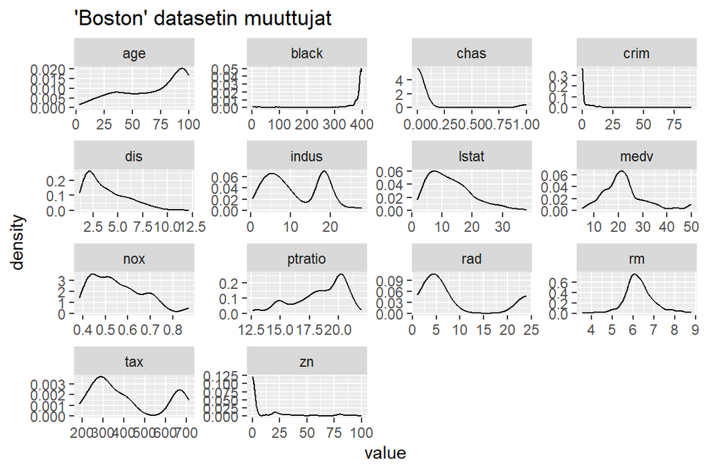

```r
# plots of variables
gather(Boston) %>% ggplot(aes(value)) +
  geom_density() +
  facet_wrap("key", scales = "free") +
  ggtitle("'Boston' datasetin muuttujat")
```

Below is a plot of correlation matrix to look at the pairwise correlations of the variables:

```r
# calculate the correlation matrix and round it
cor_matrix <- Boston %>% cor() %>% round(2)

# print the correlation matrix
cor_matrix
```

```
##          crim    zn indus  chas   nox    rm   age   dis   rad   tax ptratio
## crim     1.00 -0.20  0.41 -0.06  0.42 -0.22  0.35 -0.38  0.63  0.58    0.29
## zn      -0.20  1.00 -0.53 -0.04 -0.52  0.31 -0.57  0.66 -0.31 -0.31   -0.39
## indus    0.41 -0.53  1.00  0.06  0.76 -0.39  0.64 -0.71  0.60  0.72    0.38
## chas    -0.06 -0.04  0.06  1.00  0.09  0.09  0.09 -0.10 -0.01 -0.04   -0.12
## nox      0.42 -0.52  0.76  0.09  1.00 -0.30  0.73 -0.77  0.61  0.67    0.19
## rm      -0.22  0.31 -0.39  0.09 -0.30  1.00 -0.24  0.21 -0.21 -0.29   -0.36
## age      0.35 -0.57  0.64  0.09  0.73 -0.24  1.00 -0.75  0.46  0.51    0.26
## dis     -0.38  0.66 -0.71 -0.10 -0.77  0.21 -0.75  1.00 -0.49 -0.53   -0.23
## rad      0.63 -0.31  0.60 -0.01  0.61 -0.21  0.46 -0.49  1.00  0.91    0.46
## tax      0.58 -0.31  0.72 -0.04  0.67 -0.29  0.51 -0.53  0.91  1.00    0.46
## ptratio  0.29 -0.39  0.38 -0.12  0.19 -0.36  0.26 -0.23  0.46  0.46    1.00
## black   -0.39  0.18 -0.36  0.05 -0.38  0.13 -0.27  0.29 -0.44 -0.44   -0.18
## lstat    0.46 -0.41  0.60 -0.05  0.59 -0.61  0.60 -0.50  0.49  0.54    0.37
## medv    -0.39  0.36 -0.48  0.18 -0.43  0.70 -0.38  0.25 -0.38 -0.47   -0.51
##         black lstat  medv
## crim    -0.39  0.46 -0.39
## zn       0.18 -0.41  0.36
## indus   -0.36  0.60 -0.48
## chas     0.05 -0.05  0.18
## nox     -0.38  0.59 -0.43
## rm       0.13 -0.61  0.70
## age     -0.27  0.60 -0.38
## dis      0.29 -0.50  0.25
## rad     -0.44  0.49 -0.38
## tax     -0.44  0.54 -0.47
## ptratio -0.18  0.37 -0.51
## black    1.00 -0.37  0.33
## lstat   -0.37  1.00 -0.74
## medv     0.33 -0.74  1.00
```

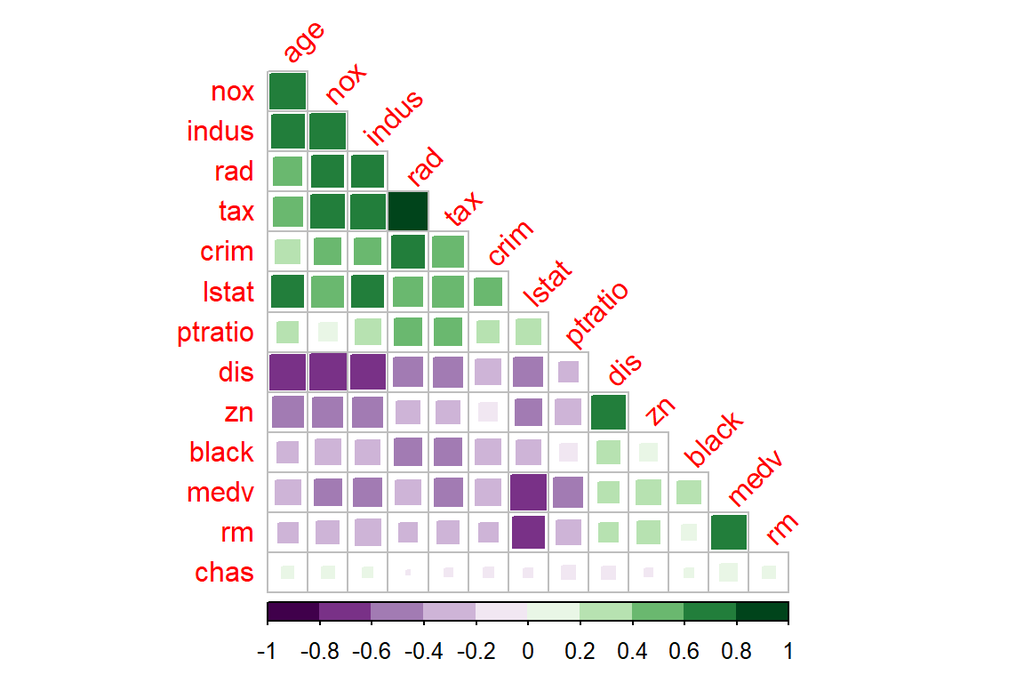

```r
# visualize the correlation matrix
library(corrplot)
corrplot(cor_matrix, method="square", order = "AOE", type = "lower", tl.srt = 45, col = COL2("PRGn", 10), diag = FALSE)
```

Looking at the visualization, we can see that at least **nox**, **indus**, **rad** and **dis** have quite high absolute pairwise correlations with other variables. It is not suprising that for example the NO-levels in air (**nox**) correlates with proportion of non-retail business acres per town (**indus**), accessibility to highways (**rad**) correlates with property taxes (**tax**) and median value of homes (**medv**) correlates with the percentage of the lower status population in the area (**lstat**).

### 4.2. Standardizing the dataset

Below I’ll scale the data by subtracting the column means from the corresponding columns and dividing the difference with standard deviation. This data standardization transforms the data with a mean of 0 and a standard deviation of 1.

```r
# center and standardize variables
boston_scaled <- as.data.frame(scale(Boston))

# summaries of the scaled variables
summary(boston_scaled)
```

```
##       crim                 zn               indus              chas
##  Min.   :-0.419367   Min.   :-0.48724   Min.   :-1.5563   Min.   :-0.2723
##  1st Qu.:-0.410563   1st Qu.:-0.48724   1st Qu.:-0.8668   1st Qu.:-0.2723
##  Median :-0.390280   Median :-0.48724   Median :-0.2109   Median :-0.2723
##  Mean   : 0.000000   Mean   : 0.00000   Mean   : 0.0000   Mean   : 0.0000
##  3rd Qu.: 0.007389   3rd Qu.: 0.04872   3rd Qu.: 1.0150   3rd Qu.:-0.2723
##  Max.   : 9.924110   Max.   : 3.80047   Max.   : 2.4202   Max.   : 3.6648
##       nox                rm               age               dis
##  Min.   :-1.4644   Min.   :-3.8764   Min.   :-2.3331   Min.   :-1.2658
##  1st Qu.:-0.9121   1st Qu.:-0.5681   1st Qu.:-0.8366   1st Qu.:-0.8049
##  Median :-0.1441   Median :-0.1084   Median : 0.3171   Median :-0.2790
##  Mean   : 0.0000   Mean   : 0.0000   Mean   : 0.0000   Mean   : 0.0000
##  3rd Qu.: 0.5981   3rd Qu.: 0.4823   3rd Qu.: 0.9059   3rd Qu.: 0.6617
##  Max.   : 2.7296   Max.   : 3.5515   Max.   : 1.1164   Max.   : 3.9566
##       rad               tax             ptratio            black
##  Min.   :-0.9819   Min.   :-1.3127   Min.   :-2.7047   Min.   :-3.9033
##  1st Qu.:-0.6373   1st Qu.:-0.7668   1st Qu.:-0.4876   1st Qu.: 0.2049
##  Median :-0.5225   Median :-0.4642   Median : 0.2746   Median : 0.3808
##  Mean   : 0.0000   Mean   : 0.0000   Mean   : 0.0000   Mean   : 0.0000
##  3rd Qu.: 1.6596   3rd Qu.: 1.5294   3rd Qu.: 0.8058   3rd Qu.: 0.4332
##  Max.   : 1.6596   Max.   : 1.7964   Max.   : 1.6372   Max.   : 0.4406
##      lstat              medv
##  Min.   :-1.5296   Min.   :-1.9063
##  1st Qu.:-0.7986   1st Qu.:-0.5989
##  Median :-0.1811   Median :-0.1449
##  Mean   : 0.0000   Mean   : 0.0000
##  3rd Qu.: 0.6024   3rd Qu.: 0.2683
##  Max.   : 3.5453   Max.   : 2.9865
```

As we can see, the variables have a mean of 0 and a standard deviation of 1.

Next I’ll create a categorical variable of the crime rate in the Boston dataset using quantiles as the break points. I’ll also remove the original variable **crim** from the scaled dataset and add new categorical value. Lastly I’ll print out the table of the new categorical variable **crime**.

```r
# create a quantile vector of crim
bins <- quantile(boston_scaled$crim)

# create a categorical variable 'crime'
crime <- cut(boston_scaled$crim, breaks = bins, include.lowest = TRUE, labels = c("low", "med_low", "med_high", "high"))

# remove original crim from the dataset
boston_scaled <- dplyr::select(boston_scaled, -crim)

# add the new categorical value to scaled data
boston_scaled <- data.frame(boston_scaled, crime)

# look at the table of the new factor crime
table(crime)
```

```
## crime
##      low  med_low med_high     high
##      127      126      126      127
```

Now we have a categorical variable of crime rate; each of the four groups being the same size.

### 4.3. Dividing the dataset

Below I’ll divide the dataset into ‘train’ and ‘test’ sets, so that random 80 % of the data is in the ‘train’ set and the rest is in the ‘test’ set.

```r
# number of rows in the Boston dataset (needed to define 80 % of the rows)
n <- nrow(boston_scaled)

# choose randomly 80% of the rows
ind <- sample(n,  size = n * 0.8)

# create train set
train <- boston_scaled[ind,]

# create test set
test <- boston_scaled[-ind,]

# save the correct classes from test data
correct_classes <- test$crime

# remove the crime variable from test data
test <- dplyr::select(test, -crime)
```

### 4.4. Linear discriminant analysis

Next I’ll fit linear discriminant analysis (LDA) to the dataset. Linear discriminant analysis finds the (linear) combination of the variables that separate the target variable classes. The target can be binary or multiclass variable. Here I’m using categorical **crime** as a target variable and the rest of the variables as predictors.

```r
# linear discriminant analysis
lda.fit <- lda(crime ~ ., data = train)

# print the lda.fit object
lda.fit
```

```
## Call:
## lda(crime ~ ., data = train)
##
## Prior probabilities of groups:
##       low   med_low  med_high      high
## 0.2450495 0.2599010 0.2400990 0.2549505
##
## Group means:
##                   zn      indus        chas        nox         rm        age
## low       0.95520732 -0.9093255 -0.11325431 -0.8855656  0.4515900 -0.9181401
## med_low  -0.09950837 -0.2604500 -0.08484810 -0.5569076 -0.1222316 -0.3298669
## med_high -0.38822494  0.1423426  0.17414622  0.3178413  0.2087844  0.4452890
## high     -0.48724019  1.0149946 -0.04298342  1.0870527 -0.4495998  0.8075600
##                 dis        rad        tax     ptratio      black       lstat
## low       0.9562314 -0.6918543 -0.7285197 -0.48195780  0.3725414 -0.76701561
## med_low   0.3450216 -0.5596728 -0.4674907 -0.02873064  0.3178353 -0.13208873
## med_high -0.3338411 -0.4443413 -0.3414466 -0.25517539  0.1525824 -0.07684199
## high     -0.8648458  1.6596029  1.5294129  0.80577843 -0.7752874  0.94404730
##                  medv
## low       0.532394388
## med_low  -0.007087805
## med_high  0.228240587
## high     -0.738074297
##
## Coefficients of linear discriminants:
##                 LD1         LD2         LD3
## zn       0.19027509  0.66824710 -0.89728583
## indus    0.04056024 -0.16929562  0.36144184
## chas    -0.09043055 -0.06911610  0.04088436
## nox      0.25181172 -0.77641896 -1.36251790
## rm      -0.17008473 -0.04647802 -0.14060226
## age      0.24683271 -0.48280624 -0.22395448
## dis     -0.17167095 -0.27651955  0.04487313
## rad      4.16462326  0.85177058 -0.14549181
## tax     -0.03719678  0.07416603  0.53780581
## ptratio  0.17835791 -0.01418403 -0.14878865
## black   -0.14974983  0.03401063  0.13226433
## lstat    0.16103659 -0.10129597  0.40827257
## medv     0.19480370 -0.32657123 -0.14718912
##
## Proportion of trace:
##    LD1    LD2    LD3
## 0.9679 0.0242 0.0079
```

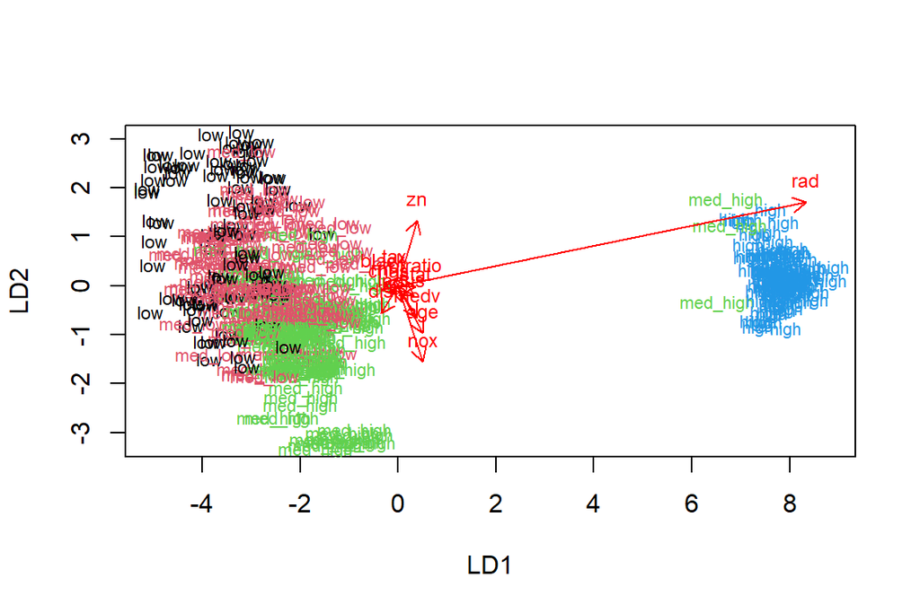

```r
# the function for lda biplot arrows
lda.arrows <- function(x, myscale = 1, arrow_heads = 0.1, color = "red", tex = 0.75, choices = c(1,2)){
  heads <- coef(x)
  graphics::arrows(x0 = 0, y0 = 0,
         x1 = myscale * heads[,choices[1]],
         y1 = myscale * heads[,choices[2]], col=color, length = arrow_heads)
  text(myscale * heads[,choices], labels = row.names(heads),
       cex = tex, col=color, pos=3)
}

# target classes as numeric
classes <- as.numeric(train$crime)

# plot the lda results
plot(lda.fit, dimen = 2, col = classes, pch = classes)
lda.arrows(lda.fit, myscale = 2)
```

Next I’ll predict the classes with LDA model on the test data and cross tabulate the results with the crime categories from the test dataset.

```r
# predict classes with test data
lda.pred <- predict(lda.fit, newdata = test)

# cross tabulate the results
table(correct = correct_classes, predicted = lda.pred$class)
```

```
##           predicted
## correct    low med_low med_high high
##   low       14      12        2    0
##   med_low    4      13        4    0
##   med_high   0       7       19    3
##   high       0       0        1   23
```

### 4.5. K-means clustering

Below I’ll load the ‘Boston’ dataset again and scale it. Then I’ll calculate the Euclidean and the Manhattan distance on it.

```r
data("Boston")
# center and standardize variables
boston_scaled2 <- as.data.frame(scale(Boston))

# euclidean distance matrix
dist_eu <- dist(boston_scaled2)

# look at the summary of the distances
summary(dist_eu)
```

```
##    Min. 1st Qu.  Median    Mean 3rd Qu.    Max.
##  0.1343  3.4625  4.8241  4.9111  6.1863 14.3970
```

```r
# manhattan distance matrix
dist_man <- dist(boston_scaled2, method="manhattan")

# look at the summary of the distances
summary(dist_man)
```

```
##    Min. 1st Qu.  Median    Mean 3rd Qu.    Max.
##  0.2662  8.4832 12.6090 13.5488 17.7568 48.8618
```

Next I’ll run k-means algorithm on the dataset ‘boston_scaled2’.

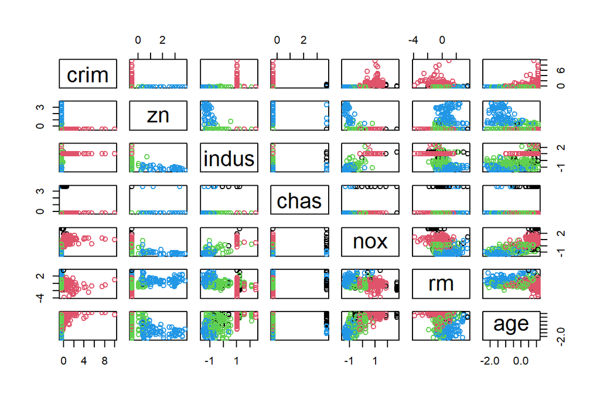

```r
# k-means clustering
km <- kmeans(boston_scaled2, centers = 4)

# plot the Boston dataset with clusters (first 7 variables)
pairs(boston_scaled2[1:7], col = km$cluster)
```

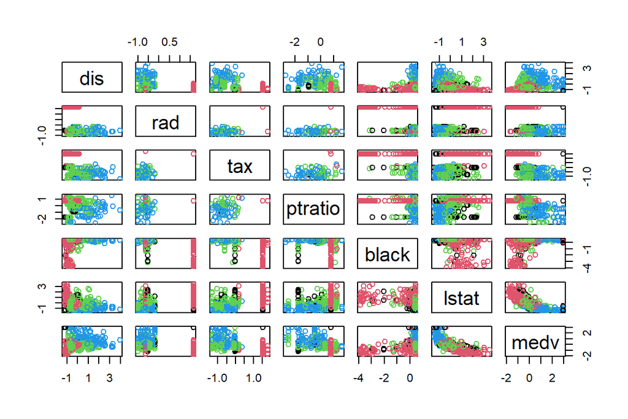

```r
# plot the Boston dataset with clusters (last 7 variables)
pairs(boston_scaled2[8:14], col = km$cluster)
```

It can be seen from the visualizations, that the clusters overlap quite a lot.

K-means needs the number of clusters as an argument and next I’ll investigate that. I’ll determine the number of clusters by looking at how the total of within cluster sum of squares (WCSS) behaves when the number of cluster changes. When plotting the number of clusters and the total WCSS, the optimal number of clusters is when the total WCSS drops radically.